# Spotify Data Exploration

Bridget Daly

9/22/2020

## Background

This project is an exploratory analysis of the “Spotify Dataset 1921-2020, 160k+ Tracks” uploaded to [kaggle](https://www.kaggle.com/yamaerenay/spotify-dataset-19212020-160k-tracks) by Yamac Eren Ay who sourced the data via the Spotify Web API. Inspiration taken from the labs in the [Introduction to Statistical Learning](http://faculty.marshall.usc.edu/gareth-james/ISL/) by Gareth James, Daniela Witten, Trevor Hastie and Robert Tibshirani. The intention is not to build the best model but rather practice with the various techniques presented in ISL.

## Data Exploration

I will first load and preview the dataset and take a look at the variable types.

```r
library(magrittr)
library(tidyverse)
library(skimr)

# for reproducibility
set.seed(22)

dat_raw <- read_csv(dat_path)
head(dat_raw)
```

```
## # A tibble: 6 x 19
##   acousticness artists danceability duration_ms energy explicit id
##          <dbl> <chr>          <dbl>       <dbl>  <dbl>    <dbl> <chr>
## 1        0.995 ['Carl…        0.708      158648 0.195         0 6KbQ…
## 2        0.994 ['Robe…        0.379      282133 0.0135        0 6KuQ…
## 3        0.604 ['Sewe…        0.749      104300 0.22          0 6L63…
## 4        0.995 ['Fran…        0.781      180760 0.13          0 6M94…
## 5        0.99  ['Fréd…        0.21       687733 0.204         0 6N6t…
## 6        0.995 ['Feli…        0.424      352600 0.12          0 6NxA…
## # … with 12 more variables: instrumentalness <dbl>, key <dbl>, liveness <dbl>,
## #   loudness <dbl>, mode <dbl>, name <chr>, popularity <dbl>,
## #   release_date <chr>, speechiness <dbl>, tempo <dbl>, valence <dbl>,
## #   year <dbl>
```

```r
skim(dat_raw) %>% select(skim_type, skim_variable, n_missing, character.n_unique)
```

Data summary

| Name | dat_raw |
| --- | --- |
| Number of rows | 169909 |
| Number of columns | 19 |
| _______________________ |  |
| Column type frequency: |  |
| character | 4 |
| numeric | 15 |
| ________________________ |  |
| Group variables | None |

**Variable type: character**

| skim_variable | n_missing | n_unique |
| --- | --- | --- |
| artists | 0 | 33375 |
| id | 0 | 169909 |
| name | 0 | 132940 |
| release_date | 0 | 10882 |

**Variable type: numeric**

| skim_variable | n_missing |
| --- | --- |
| acousticness | 0 |
| danceability | 0 |
| duration_ms | 0 |
| energy | 0 |
| explicit | 0 |
| instrumentalness | 0 |
| key | 0 |
| liveness | 0 |
| loudness | 0 |
| mode | 0 |
| popularity | 0 |
| speechiness | 0 |
| tempo | 0 |
| valence | 0 |
| year | 0 |

From this summary I see there are 169909 rows in the dataset, unique by the character attribute `id`, Spotify’s track identifier. There is no missing data in any column. Aside from id, there are three other character attributes: `artists`, `name`, and `release_date`. I want to dive deeper into the `artists` column. There are 33375 unique artists, so naively dividing the number of tracks by the number of artists yields an average of 5 tracks per artist.

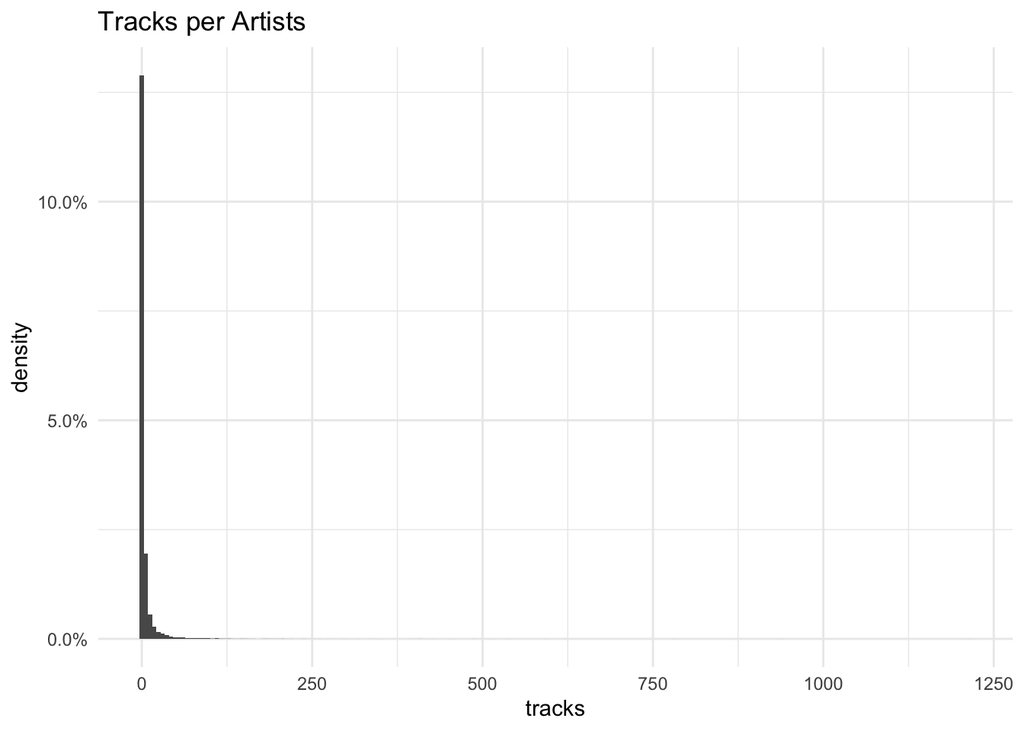

```r
dat_raw %>% group_by(artists) %>%
  summarise(tracks = n()) %>%
  ggplot(aes(tracks, y = ..density..)) +
  geom_histogram(bins = 200) +
  scale_y_continuous(labels = scales::percent) +
  theme_minimal() +
  ggtitle("Tracks per Artists")
```

The histogram for this metric shows that tracks per artist is right-skewed with a long tail. Who are the most prolific artists?

```r
dat_raw %>% group_by(artists) %>%
  summarise(tracks = n()) %>%
  arrange(desc(tracks)) %>%
  head(10)
```

```
## # A tibble: 10 x 2
##    artists                tracks
##    <chr>                   <int>
##  1 ['Эрнест Хемингуэй']     1215
##  2 ['Francisco Canaro']      938
##  3 ['Эрих Мария Ремарк']     781
##  4 ['Ignacio Corsini']       620
##  5 ['Frank Sinatra']         592
##  6 ['Bob Dylan']             539
##  7 ['The Rolling Stones']    512
##  8 ['Johnny Cash']           502
##  9 ['The Beach Boys']        491
## 10 ['Elvis Presley']         488
```

Two of the top three artists are actually Russian spellings of authors: Эрнест Хемингуэй is Ernest Hemmingway and Эрих Мария Ремарк Erich Maria Remarque. Perhaps these “tracks” are audio recordings of their works. Removing the artists with the top 1% of tracks gives a cleaner look at tracks per artist, which is still very right-skewed.

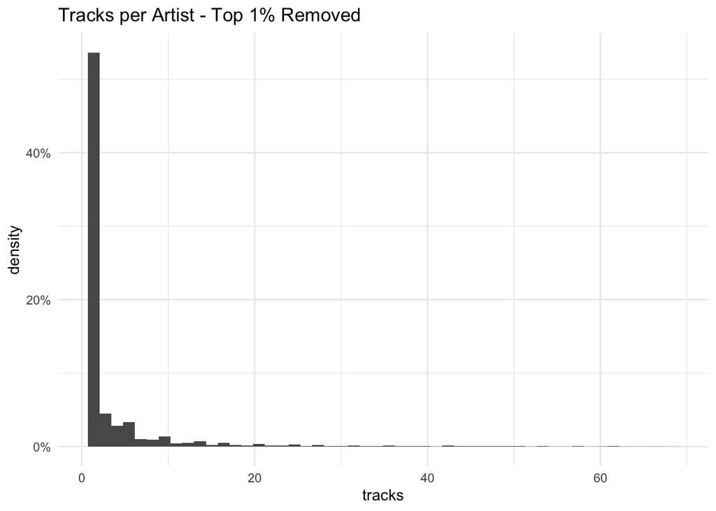

```r
dat_raw %>% group_by(artists) %>%
  summarise(tracks = n()) %>%
  ungroup() %>%
  filter(tracks < quantile(tracks, 0.99)) %>%
  ggplot(aes(tracks, y = ..density..)) +
  geom_histogram(bins = 50) +
  scale_y_continuous(labels = scales::percent) +
  theme_minimal() +
  ggtitle("Tracks per Artist - Top 1% Removed")
```

One reason for the strong right skew is that each unique collaboration is treated as an independent artist. Let’s use Imagine Dragons as an example. We can see that Imagine Dragons has 55 tracks, but they also have 5 unique collaborations with other artists. Each of these collaborations is counted as an artist with 1-2 tracks, skewing the tracks per artist metric. One solution is to remove collaborations entirely. Another is to credit each track to each collaborating artist. I’ll apply these two methods to this dataset.

```r
dat_raw %>% group_by(artists) %>%
  summarise(tracks = n()) %>%
  filter(str_detect(artists,"Imagine Dragons"))
```

```
## # A tibble: 6 x 2
##   artists                                                                 tracks
##   <chr>                                                                    <int>
## 1 ['Imagine Dragons', 'Broiler']                                               1
## 2 ['Imagine Dragons', 'Kendrick Lamar']                                        1
## 3 ['Imagine Dragons', 'Khalid']                                                1
## 4 ['Imagine Dragons']                                                         55
## 5 ['Kygo', 'Imagine Dragons']                                                  1
## 6 ['Lil Wayne', 'Wiz Khalifa', 'Imagine Dragons', 'X Ambassadors', 'Logi…      2
```

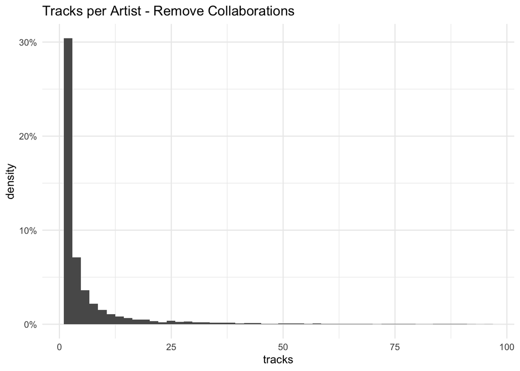

```r
# Remove collaborations
dat_raw %>% select(artists, id) %>%
  mutate(listartists = str_split(artists,",")) %>%
  rowwise() %>%
  mutate(numartists = length(listartists)) %>%
  filter(numartists == 1) %>%
  group_by(artists) %>%
  summarise(tracks = n()) %>%
  ungroup() %>%
  filter(tracks < quantile(tracks, 0.99)) %>%
  ggplot(aes(tracks, y = ..density..)) +
  geom_histogram(bins = 50) +
  scale_y_continuous(labels = scales::percent) +
  theme_minimal() +
  ggtitle("Tracks per Artist - Remove Collaborations")
```

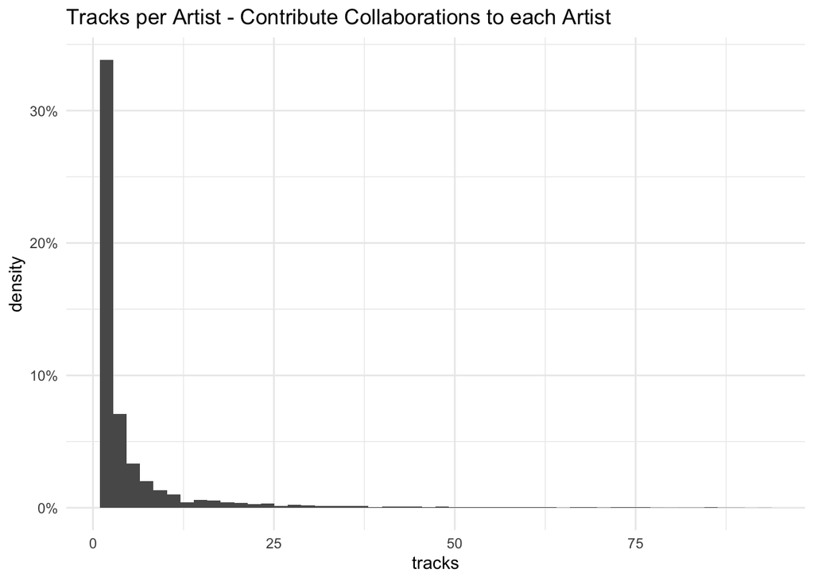

```r
# Credit collaborations to each artist
dat_raw %>% select(artists, id) %>%
  mutate(artists = str_remove_all(artists,"\\[|\\]")) %>%
  separate_rows(artists, sep = ",") %>%
  group_by(artists) %>%
  summarise(tracks = n()) %>%
  ungroup() %>%
  filter(tracks < quantile(tracks, 0.99)) %>%
  ggplot(aes(tracks, y = ..density..)) +
  geom_histogram(bins = 50) +
  scale_y_continuous(labels = scales::percent) +
  theme_minimal() +
  ggtitle("Tracks per Artist - Contribute Collaborations to each Artist")
```

Both of these methods reduce the number of artists with one song as expected. The number of artists featured on a track might be interesting to have down the line, so I will create a new feature `num_artists` before moving on.

```r
dat_raw %<>% mutate(listartists = str_split(artists,",")) %>%
  rowwise() %>%
  mutate(num_artists = length(listartists)) %>%
  select(-listartists) %>%
  ungroup()
```

Another character variable that might be interesting to explore further is `release_date`. It would make sense to treat this as a date variable instead of a character variable; however, converting this column to a date will throw an error because the format of the release_date column is inconsistent. A quick check on the length of each entry shows that we have three formats present: 69% have the full date in format YYYY-MM-DD, 29% have only the year in format YYYY, and the remaining 1 % have the month and year in format YYYY-MM.

```r
dat_raw["release_date"] = as.Date(dat_raw["release_date"])
```

```
## Error in as.Date.default(dat_raw["release_date"]): do not know how to convert 'dat_raw["release_date"]' to class "Date"
```

```r
dat_raw %>% select(release_date) %>%
  mutate(length_release_date = nchar(release_date)) %>%
  group_by(length_release_date) %>%
  summarise(rows = n(),
            pct_rows = round(rows/nrow(dat_raw)*100,1))
```

```
## # A tibble: 3 x 3
##   length_release_date   rows pct_rows
##                 <int>  <int>    <dbl>
## 1                   4  50382     29.7
## 2                   7   1649      1
## 3                  10 117878     69.4
```

This data spans almost 100 years, so year seems acceptable as the most granular level of date data for my use cases. From our summary above, there is already a `year` column which I will use instead of `release_date`. I want to get a sense of the distribution of tracks through the years.

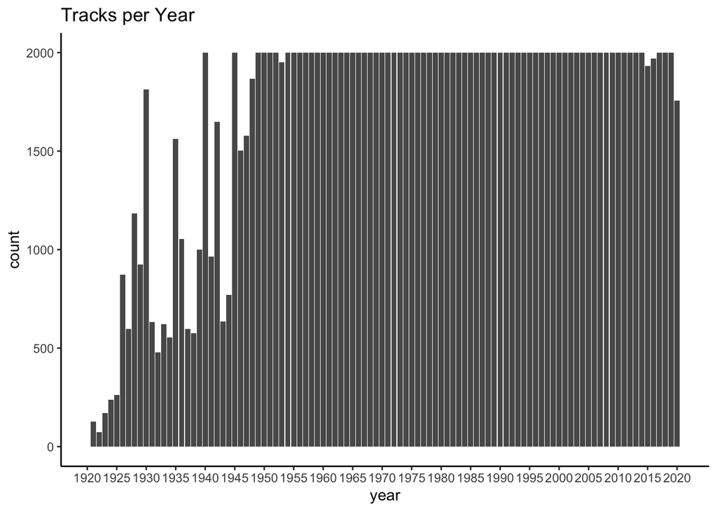

```r
dat_raw %>% ggplot(aes(x=year)) +
  geom_bar() +
  scale_x_continuous(breaks = seq(1920,2020,5)) +
  theme_classic() +
  ggtitle("Tracks per Year")
```

From 1949 to present, the dataset has been capped at 2000 tracks per year, so there is a uniform distribution excluding the early 20th century. Year might still be too granular for some use cases, so I will create a new factor variable, `decade`, grouping every 10 years together beginning with 1921 (i.e. the first will be 1921-1930 and the last will be 2011-2020).

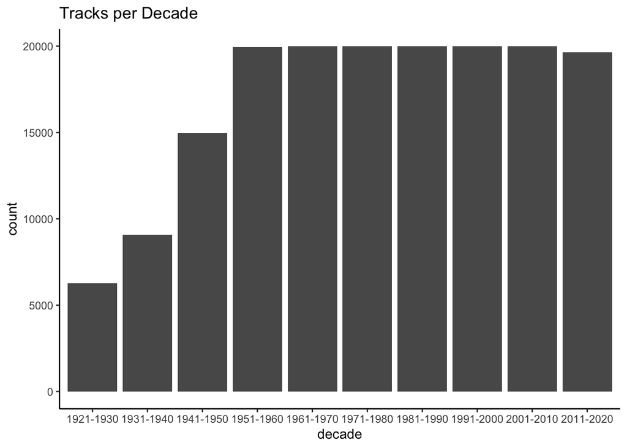

```r
dat_raw %<>% mutate(decade = factor(case_when(year < 1931 ~ "1921-1930",
                                              year < 1941 ~ "1931-1940",
                                              year < 1951 ~ "1941-1950",
                                              year < 1961 ~ "1951-1960",
                                              year < 1971 ~ "1961-1970",
                                              year < 1981 ~ "1971-1980",
                                              year < 1991 ~ "1981-1990",
                                              year < 2001 ~ "1991-2000",
                                              year < 2011 ~ "2001-2010",
                                              year < 2021 ~ "2011-2020")))

dat_raw %>% ggplot(aes(x=decade)) +
  geom_bar() +
  theme_classic() +
  ggtitle("Tracks per Decade")
```

I know from the data documentation that a few of the other variables should be factors as well. Two of the numerical variables, `mode` and `explicit`, are dummy variables. `mode` has a value of 0 for minor and 1 for major while `explicit` has a value of 0 for not explicit and 1 for explicit. `key` is a categorical variable taking on values 0 to 11 for each of the octaves.

```r
fact_cols = c("mode","explicit","key")
dat_raw[fact_cols] <- lapply(dat_raw[fact_cols], factor)
```

Now I can move on to explore the 11 remaining numeric attributes describing musical qualities of the track.

```r
skim(dat_raw)
```

Data summary

| Name | dat_raw |
| --- | --- |
| Number of rows | 169909 |
| Number of columns | 21 |
| _______________________ |  |
| Column type frequency: |  |
| character | 4 |
| factor | 4 |
| numeric | 13 |
| ________________________ |  |
| Group variables | None |

**Variable type: character**

| skim_variable | n_missing | complete_rate | min | max | empty | n_unique | whitespace |
| --- | --- | --- | --- | --- | --- | --- | --- |
| artists | 0 | 1 | 5 | 661 | 0 | 33375 | 0 |
| id | 0 | 1 | 22 | 22 | 0 | 169909 | 0 |
| name | 0 | 1 | 1 | 255 | 0 | 132940 | 0 |
| release_date | 0 | 1 | 4 | 10 | 0 | 10882 | 0 |

**Variable type: factor**

| skim_variable | n_missing | complete_rate | ordered | n_unique | top_counts |
| --- | --- | --- | --- | --- | --- |
| explicit | 0 | 1 | FALSE | 2 | 0: 155490, 1: 14419 |
| key | 0 | 1 | FALSE | 12 | 0: 21499, 7: 20757, 2: 18821, 9: 17628 |
| mode | 0 | 1 | FALSE | 2 | 1: 120390, 0: 49519 |
| decade | 0 | 1 | FALSE | 10 | 196: 20000, 197: 20000, 198: 20000, 199: 20000 |

**Variable type: numeric**

| skim_variable | n_missing | complete_rate | mean | sd | p0 | p25 | p50 | p75 | p100 | hist |
| --- | --- | --- | --- | --- | --- | --- | --- | --- | --- | --- |
| acousticness | 0 | 1 | 0.49 | 0.38 | 0 | 0.09 | 0.49 | 0.89 | 1.00 | ▇▃▂▃▇ |
| danceability | 0 | 1 | 0.54 | 0.18 | 0 | 0.42 | 0.55 | 0.67 | 0.99 | ▁▃▇▇▂ |
| duration_ms | 0 | 1 | 231406.16 | 121321.92 | 5108 | 171040.00 | 208600.00 | 262960.00 | 5403500.00 | ▇▁▁▁▁ |
| energy | 0 | 1 | 0.49 | 0.27 | 0 | 0.26 | 0.48 | 0.71 | 1.00 | ▆▇▇▇▆ |
| instrumentalness | 0 | 1 | 0.16 | 0.31 | 0 | 0.00 | 0.00 | 0.09 | 1.00 | ▇▁▁▁▁ |
| liveness | 0 | 1 | 0.21 | 0.18 | 0 | 0.10 | 0.14 | 0.26 | 1.00 | ▇▃▁▁▁ |
| loudness | 0 | 1 | -11.37 | 5.67 | -60 | -14.47 | -10.47 | -7.12 | 3.86 | ▁▁▁▇▆ |
| popularity | 0 | 1 | 31.56 | 21.58 | 0 | 12.00 | 33.00 | 48.00 | 100.00 | ▇▇▇▂▁ |
| speechiness | 0 | 1 | 0.09 | 0.15 | 0 | 0.03 | 0.04 | 0.08 | 0.97 | ▇▁▁▁▁ |
| tempo | 0 | 1 | 116.95 | 30.73 | 0 | 93.52 | 114.78 | 135.71 | 244.09 | ▁▅▇▂▁ |
| valence | 0 | 1 | 0.53 | 0.26 | 0 | 0.32 | 0.54 | 0.75 | 1.00 | ▅▇▇▇▆ |
| year | 0 | 1 | 1977.22 | 25.59 | 1921 | 1957.00 | 1978.00 | 1999.00 | 2020.00 | ▃▇▇▇▇ |
| num_artists | 0 | 1 | 1.33 | 0.91 | 1 | 1.00 | 1.00 | 1.00 | 40.00 | ▇▁▁▁▁ |

7 of the variables - `acousticness`, `danceability`, `energy`, `instrumentalness`, `liveness`, `speechiness`, and `valence` - are Spotify derived metrics on a 0 to 1 scale. `duration_ms`, `loudness` (dB), and `tempo` (BPM) describe standard musical characteristics. Finally, `popularity` is a Spotify derived metric ranging from 0 to 100 based primarily on number and recency of plays. The `skimr` summary above provides a sense of the distribution across tracks of each of these variables. Some, such as `danceability` and `tempo` look aproximately normally distributed. Many exhibit strong right skews, such as `instrumntalness` and `liveness`. `acousticness` has a bimodal distribution, with most songs either very clearly acoustic or not at all. I am interested in exploring any correlations that might exist between these variables.

```r
cor(select_if(dat_raw, is.numeric) %>% select(-num_artists,-year))
```

```
##                  acousticness danceability duration_ms      energy
## acousticness       1.00000000 -0.265950251 -0.07931112 -0.75028307
## danceability      -0.26595025  1.000000000 -0.13449985  0.22056881
## duration_ms       -0.07931112 -0.134499848  1.00000000  0.03639552
## energy            -0.75028307  0.220568806  0.03639552  1.00000000
## instrumentalness   0.33582105 -0.281428663  0.08481437 -0.28769152
## liveness          -0.02387056 -0.105532476  0.03427004  0.12629302
## loudness          -0.56707180  0.294169938 -0.01468714  0.78298168
## popularity        -0.59334520  0.221076890  0.06329178  0.49748834
## speechiness       -0.05607702  0.225304630 -0.05844907 -0.04522623
## tempo             -0.20498168 -0.004871758 -0.02881602  0.24993569
## valence           -0.18553983  0.560242182 -0.19875954  0.35008554
##                  instrumentalness      liveness    loudness   popularity
## acousticness           0.33582105 -0.0238705569 -0.56707180 -0.593345200
## danceability          -0.28142866 -0.1055324762  0.29416994  0.221076890
## duration_ms            0.08481437  0.0342700441 -0.01468714  0.063291780
## energy                -0.28769152  0.1262930218  0.78298168  0.497488336
## instrumentalness       1.00000000 -0.0473971355 -0.41703328 -0.299829234
## liveness              -0.04739714  1.0000000000  0.05298457 -0.075292771
## loudness              -0.41703328  0.0529845674  1.00000000  0.466546009
## popularity            -0.29982923 -0.0752927708  0.46654601  1.000000000
## speechiness           -0.11573490  0.1476673853 -0.10579640 -0.135706614
## tempo                 -0.10757018  0.0081239392  0.21111421  0.135046993
## valence               -0.19392918 -0.0004263233  0.30841801  0.009326926
##                  speechiness        tempo       valence
## acousticness     -0.05607702 -0.204981677 -0.1855398334
## danceability      0.22530463 -0.004871758  0.5602421818
## duration_ms      -0.05844907 -0.028816023 -0.1987595410
## energy           -0.04522623  0.249935691  0.3500855444
## instrumentalness -0.11573490 -0.107570175 -0.1939291790
## liveness          0.14766739  0.008123939 -0.0004263233
## loudness         -0.10579640  0.211114207  0.3084180113
## popularity       -0.13570661  0.135046993  0.0093269260
## speechiness       1.00000000 -0.010069584  0.0563833378
## tempo            -0.01006958  1.000000000  0.1711815775
## valence           0.05638334  0.171181578  1.0000000000
```

## Predicting Popularity

Now that I am familiar with the data, I would like to determine whether a track’s popularity can be predicted given its musical attributes. I’ll start by taking a closer look at the variable `popularity`.

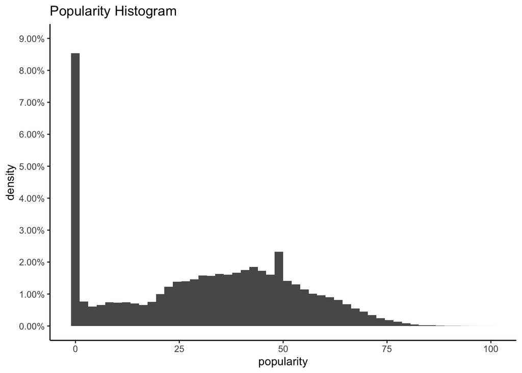

```r
dat_raw %>% ggplot(aes(x=popularity, y = ..density..)) +
  geom_histogram(bins = 50,) +
  scale_y_continuous(labels = scales::percent, breaks = seq(0,.09,.01), limits = c(0,.09)) +
  theme_classic() +
  ggtitle("Popularity Histogram")
```

Popularity is right skewed. About 8-9% of tracks have a popularity of 0. Less than 1% (0.0086988 to be precise) have a popularity over 75. Because Spotify’s algorithm promotes recency of plays, I’ll check out popularity by year.

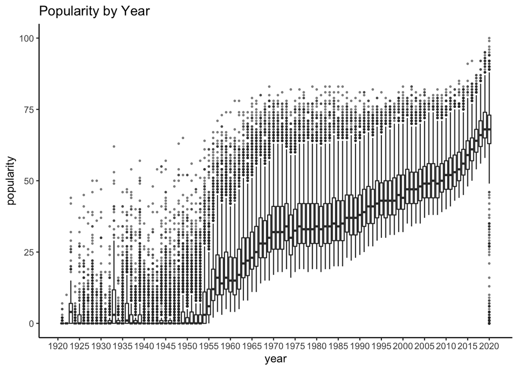

```r
dat_raw %>% ggplot(aes(y=popularity, x=year, group=year)) +
  geom_boxplot(outlier.size = 0.5, outlier.alpha = 0.5) +
  scale_x_continuous(breaks = seq(1920,2020,5)) +
  theme_classic() +
  ggtitle("Popularity by Year")
```

Popularity clearly increases with year. This makes sense, as songs recently released are the ones many people will be playing most often on Spotify.

### Linear Regression

I will start by building an ordinary least squares linear regression model to predict popularity. First I will remove the character variables (`artists`, `id`, `name`, and `release_date`) and `decade` which is correlated with year, leaving 15 predictors for `popularity`. Next I will divide my data into a training set and a testing set 80:20 to better judge the model’s performance. (If I were truly interested in building the best model I would include a validation set to compare the various models before using the test set only on the final model.)

```r
dat_model = dat_raw %>% select_if(negate(is.character)) %>% select(-decade)

train_ind = sample(nrow(dat_model),floor(.8*nrow(dat_model)))
dat_train = dat_model[train_ind,]
dat_test = dat_model[-train_ind,]
```

Finally, I can fit the linear regression model.

```r
# model
lm.fit=lm(popularity~.,data=dat_train)
summary(lm.fit)
```

```
##
## Call:
## lm(formula = popularity ~ ., data = dat_train)
##
## Residuals:
##     Min      1Q  Median      3Q     Max
## -64.843  -7.157  -1.609   5.301  61.838
##
## Coefficients:
##                    Estimate Std. Error  t value Pr(>|t|)
## (Intercept)      -1.316e+03  3.057e+00 -430.370  < 2e-16 ***
## acousticness     -3.781e+00  1.272e-01  -29.737  < 2e-16 ***
## danceability      4.490e+00  2.181e-01   20.591  < 2e-16 ***
## duration_ms       8.372e-07  2.319e-07    3.611 0.000305 ***
## energy           -9.040e-01  2.263e-01   -3.995 6.46e-05 ***
## explicit1         6.523e-01  1.166e-01    5.596 2.20e-08 ***
## instrumentalness -2.608e+00  1.026e-01  -25.431  < 2e-16 ***
## key1             -1.379e-01  1.257e-01   -1.097 0.272530
## key2             -1.756e-01  1.119e-01   -1.569 0.116623
## key3             -2.104e-01  1.530e-01   -1.376 0.168950
## key4              7.893e-02  1.256e-01    0.628 0.529775
## key5             -5.866e-02  1.167e-01   -0.503 0.615212
## key6             -1.422e-01  1.436e-01   -0.990 0.322041
## key7             -1.779e-01  1.088e-01   -1.636 0.101942
## key8             -1.812e-01  1.326e-01   -1.367 0.171561
## key9              3.423e-02  1.140e-01    0.300 0.764026
## key10            -1.738e-01  1.277e-01   -1.361 0.173671
## key11            -5.293e-01  1.343e-01   -3.940 8.14e-05 ***
## liveness         -2.412e+00  1.610e-01  -14.979  < 2e-16 ***
## loudness          1.309e-02  8.590e-03    1.524 0.127560
## mode1            -2.869e-01  6.175e-02   -4.646 3.39e-06 ***
## speechiness      -7.663e+00  2.193e-01  -34.937  < 2e-16 ***
## tempo             3.644e-03  9.318e-04    3.910 9.22e-05 ***
## valence          -5.924e-01  1.490e-01   -3.977 6.99e-05 ***
## year              6.828e-01  1.532e-03  445.804  < 2e-16 ***
## num_artists      -8.497e-01  3.121e-02  -27.222  < 2e-16 ***
## ---
## Signif. codes:  0 '***' 0.001 '**' 0.01 '*' 0.05 '.' 0.1 ' ' 1
##
## Residual standard error: 10 on 135901 degrees of freedom
## Multiple R-squared:  0.7853, Adjusted R-squared:  0.7852
## F-statistic: 1.988e+04 on 25 and 135901 DF,  p-value: < 2.2e-16
```

From this summary, the F test has a p-value of <2.2e-16 indicating at least one significant independent variable. The t tests of the individual coefficients indicate that all but `loudness` and ten of the eleven dummy variables for key are significant with p-values well below .05. On average, popularity will deviate by 10 from the “true” regression line as provided by the residual standard error. Finally, this first attempt at a linear model has a respectable R^2 value of .78 meaning 78% of the variability in popularity can be explained using this set of predictors. Before checking our test data, let’s perform some further diagnostics.

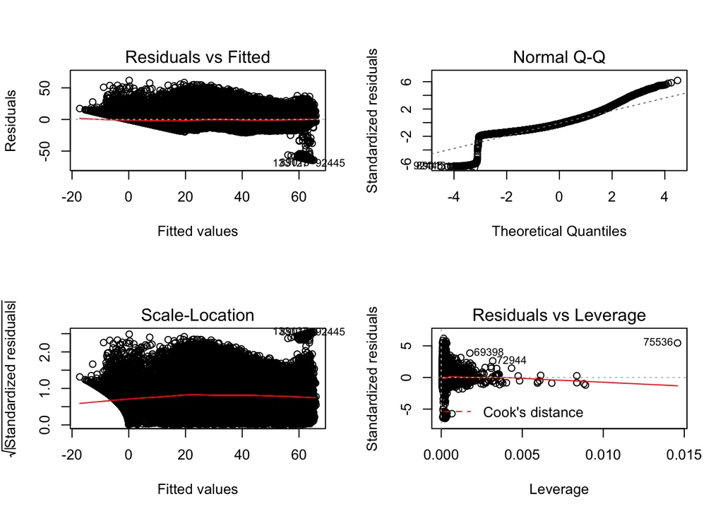

```r
# check residuals and leverage
par(mfrow=c(2,2))
plot(lm.fit)
```

```r
# check collinearity
regclass::VIF(lm.fit)
```

```
##                      GVIF Df GVIF^(1/(2*Df))
## acousticness     3.117059  1        1.765519
## danceability     1.987423  1        1.409760
## duration_ms      1.085475  1        1.041861
## energy           4.965852  1        2.228419
## explicit         1.430589  1        1.196072
## instrumentalness 1.366279  1        1.168879
## key              1.119450 11        1.005142
## liveness         1.105573  1        1.051462
## loudness         3.214362  1        1.792864
## mode             1.069599  1        1.034214
## speechiness      1.470249  1        1.212538
## tempo            1.113553  1        1.055250
## valence          2.078437  1        1.441679
## year             2.089034  1        1.445349
## num_artists      1.089557  1        1.043819
```

The residual plot should not have any clear patterns. A pattern could indicate non-linearity and a funnel-shaped pattern specifically could indicate heteroskedasticity, or a violation of our assumption that the error terms have equal variance. The smoothing line of the residual plot is horizontal at zero, but the residuals do not look completely random because of the bunch of negative residuals at the largest fitted values and the angled negative residual cutoff of the lowest fitted values. The scale-location plot indicates the same information about our residuals. The QQ plot checks the assumption that errors are normally distributed. The residuals have a slight curve and especially stray from the straight line at the extremes indicating more extreme values than expected from a normal distribution or “fat-tails”. Looking at the leverage plot, there is one standout high-leverage observation in the top right (75536) that could be influencing coefficients. Finally, all variance inflation factors are below 5 so there does not appear to be collinearity among the variables.

The normal distribution violation and inability to handle the constraint of our response value being between 0 and 100 suggests that OLS linear regression might not be the best fit for this data. For the sake of later model comparison, I will remove loudness and key, the insignificant predictors, and remove the high-leverage observation before using this model to predict the popularity of songs in our test set.

```r
# remove high leverage observation
dat_train2 <- dat_train[-75536,]

# model
lm.fit2=lm(popularity~.-loudness-key,data=dat_train2)
summary(lm.fit2)
```

```
##
## Call:
## lm(formula = popularity ~ . - loudness - key, data = dat_train2)
##
## Residuals:
##     Min      1Q  Median      3Q     Max
## -64.822  -7.147  -1.612   5.294  61.823
##
## Coefficients:
##                    Estimate Std. Error  t value Pr(>|t|)
## (Intercept)      -1.316e+03  3.033e+00 -433.937  < 2e-16 ***
## acousticness     -3.742e+00  1.248e-01  -29.971  < 2e-16 ***
## danceability      4.534e+00  2.147e-01   21.122  < 2e-16 ***
## duration_ms       8.446e-07  2.318e-07    3.644 0.000269 ***
## energy           -6.978e-01  1.742e-01   -4.005 6.22e-05 ***
## explicit1         6.570e-01  1.158e-01    5.676 1.38e-08 ***
## instrumentalness -2.662e+00  9.730e-02  -27.365  < 2e-16 ***
## liveness         -2.414e+00  1.608e-01  -15.012  < 2e-16 ***
## mode1            -2.727e-01  6.023e-02   -4.527 5.98e-06 ***
## speechiness      -7.773e+00  2.148e-01  -36.196  < 2e-16 ***
## tempo             3.745e-03  9.307e-04    4.024 5.71e-05 ***
## valence          -6.092e-01  1.485e-01   -4.104 4.07e-05 ***
## year              6.829e-01  1.528e-03  446.828  < 2e-16 ***
## num_artists      -8.751e-01  3.138e-02  -27.891  < 2e-16 ***
## ---
## Signif. codes:  0 '***' 0.001 '**' 0.01 '*' 0.05 '.' 0.1 ' ' 1
##
## Residual standard error: 10 on 135912 degrees of freedom
## Multiple R-squared:  0.7853, Adjusted R-squared:  0.7853
## F-statistic: 3.824e+04 on 13 and 135912 DF,  p-value: < 2.2e-16
```

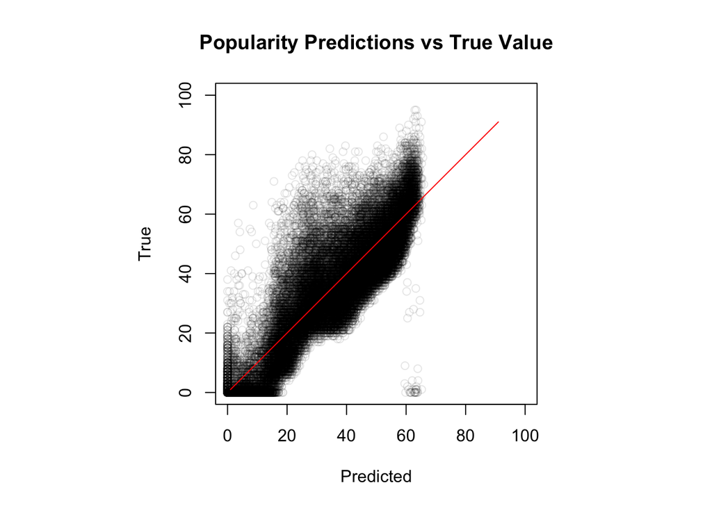

```r
# predict
lm.predicts = predict(lm.fit2, dat_test)
lm.predicts[lm.predicts < 0] = 0
lm.predicts[lm.predicts > 100] = 100
lm.mse = mean((dat_test$popularity - lm.predicts)^2)
par(pty="s")
plot(lm.predicts, dat_test$popularity, xlim=c(0,100), ylim=c(0,100), col=alpha("black",.1), xlab="Predicted", ylab="True", main="Popularity Predictions vs True Value")
lines(seq(1,100,10),seq(1,100,10),col="red")
```

Predictions less than 0 are forced to 0 and greater than 100 to 100 given that popularity can only take on values 0 to 100. The mean squared error (MSE) is 98.9216885 which will be a helpful metric to use to compare future models to this linear model. From the plot of the predicted vs true values, it appears that this model does not do a great job of predicting the most popular songs as the maximum prediction is 65.98.

Although this model might not be incredibly helpful in predicting the most popular songs, one benefit of linear regression is the interpretability of the model coefficients. For example, the coefficient for acousticness is -3.742 indicating that an increase of 1 in acousticness holding all other predictors constant is predicted to lead to a decrease in popularity of 3.7. Speechiness, liveness, and instrumentalness also drive popularity down, while danceability has the most positive impact on popularity.

### Lasso Regression

Although our model has a reasonable number of predictors and all appear to be significant, I am curious to see if certain variables will be excluded using lasso regression. I will use cross-validation to obtain the best lambda.

```r
library(glmnet)
```

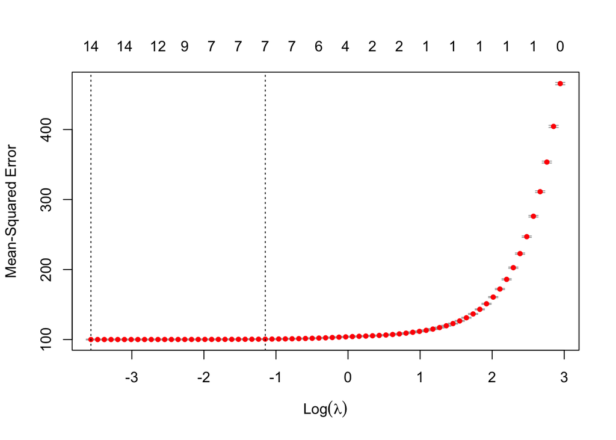

```r
lasso.fit=glmnet(data.matrix(select(dat_train2,-popularity)),dat_train2$popularity,alpha=1)
lasso.cv=cv.glmnet(data.matrix(select(dat_train2,-popularity)),dat_train2$popularity,alpha=1)
plot(lasso.cv)
```

The best lambda is 0.03 which is very close to zero indicating that all variables should remain in the model as initially believed.

### Decision Trees

Another technique for prediction is a regression decision tree.

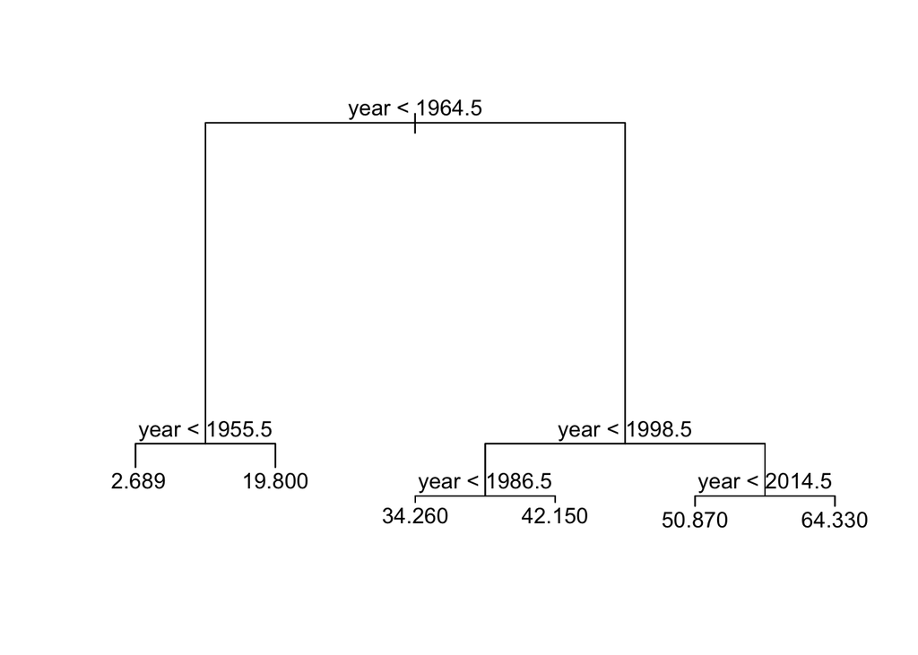

```r
library(tree)
tree.fit = tree(popularity~.,dat_train)
plot(tree.fit)
text(tree.fit)
```

```r
tree.predicts = predict(tree.fit, dat_test)
tree.predicts[tree.predicts < 0] = 0
tree.predicts[tree.predicts > 100] = 100
tree.mse = mean((dat_test$popularity - tree.predicts)^2)
```

This tree only uses year to predict popularity and actually outperforms the linear regression model, with a mean squared error of 92.2629542. I bet we can improve the prediction further by using a random forest. To reduce the time needed to train the random forest, I will only use a small fraction of the training data.

```r
library(randomForest)
reduced_samp = sample(nrow(dat_train),floor(.1*nrow(dat_train)))
dat_train_reduced = dat_train[reduced_samp,]
rf.fit = randomForest(popularity~.,dat_train_reduced,importance=TRUE)

rf.predicts = predict(rf.fit, dat_test)
rf.predicts[rf.predicts < 0] = 0
rf.predicts[rf.predicts > 100] = 100
rf.mse = mean((dat_test$popularity - rf.predicts)^2)

importance(rf.fit)
```

```
##                     %IncMSE IncNodePurity
## acousticness      20.537630     867326.81
## danceability      30.927080     113737.11
## duration_ms       23.109153     186571.90
## energy            21.636386     431314.64
## explicit          20.557314      54961.01
## instrumentalness  25.983418     137144.25
## key                1.205656     152497.24
## liveness           8.778255      95522.03
## loudness          25.059632     377915.01
## mode               1.810002      10410.91
## speechiness       22.112880     175197.98
## tempo             15.728450      90980.03
## valence           24.072540     105691.19
## year             233.254325    3506197.95
## num_artists       15.768071      33036.32
```

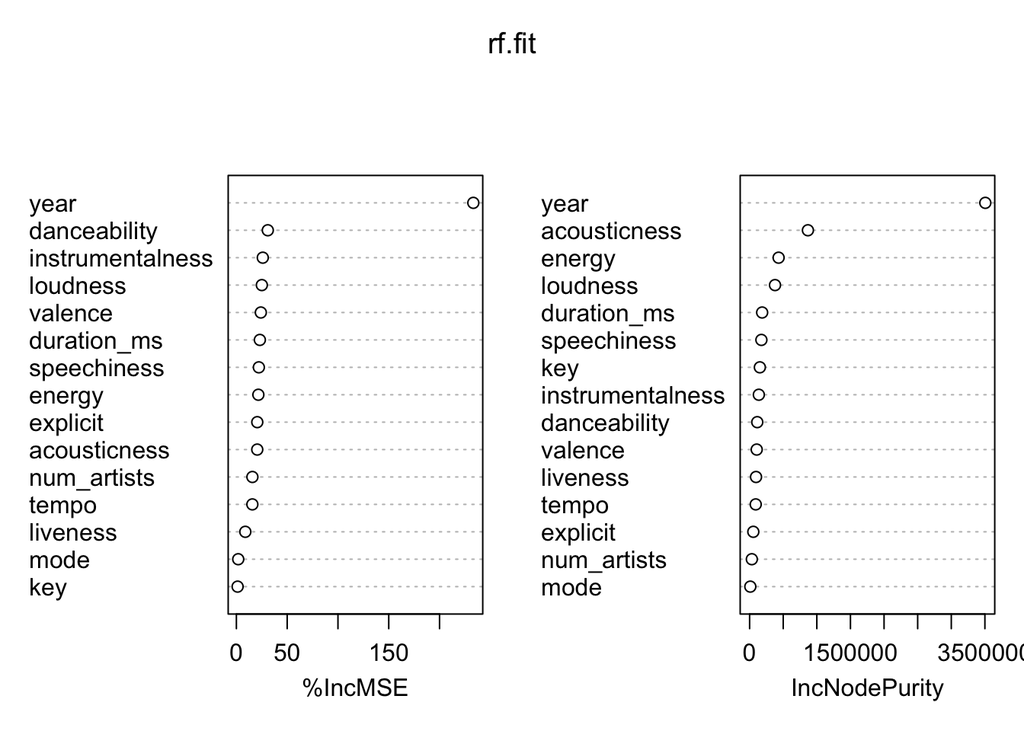

```r
varImpPlot(rf.fit)
```

As expected, the MSE of the random forest is the lowest achieved at 84.5603873. Using the full training dataset and exploring parameters using a validation set would also likely further improve the MSE. We can also explore the variable importance using the random forest results. The plot indicates that year is clearly the most important variable in predicting popularity.

## Classification

In order to predict popularity, I tried several methods intended for a quantitative response variable. Now, I will explore classification techniques with the qualitative variable `explicit`, the 0/1 indicator flagging a song for explicit lyrics.

### Logistic Regression

First, I will try predicting whether or not a song is explicit using logistic regression and the same train/test split from above.

```r
glm.fit = glm(explicit~., data=dat_train, family=binomial)
summary(glm.fit)
```

```
##
## Call:
## glm(formula = explicit ~ ., family = binomial, data = dat_train)
##
## Deviance Residuals:
##     Min       1Q   Median       3Q      Max
## -3.3376  -0.2344  -0.0783  -0.0225   4.8151
##
## Coefficients:
##                    Estimate Std. Error z value Pr(>|z|)
## (Intercept)      -1.132e+02  2.842e+00 -39.821  < 2e-16 ***
## acousticness     -2.777e+00  6.807e-02 -40.805  < 2e-16 ***
## danceability      3.962e+00  1.065e-01  37.206  < 2e-16 ***
## duration_ms      -3.072e-06  1.815e-07 -16.925  < 2e-16 ***
## energy           -9.307e-01  1.104e-01  -8.428  < 2e-16 ***
## instrumentalness -5.189e-01  9.914e-02  -5.234 1.66e-07 ***
## key1              3.329e-01  5.365e-02   6.205 5.46e-10 ***
## key2             -6.078e-02  5.828e-02  -1.043 0.297035
## key3             -3.051e-01  9.558e-02  -3.192 0.001411 **
## key4             -2.915e-02  6.391e-02  -0.456 0.648286
## key5             -1.872e-01  6.384e-02  -2.933 0.003354 **
## key6              8.602e-02  6.130e-02   1.403 0.160525
## key7              4.505e-02  5.506e-02   0.818 0.413251
## key8             -9.902e-04  6.390e-02  -0.015 0.987637
## key9             -1.871e-01  6.007e-02  -3.115 0.001842 **
## key10            -9.824e-02  6.470e-02  -1.519 0.128871
## key11             2.227e-01  5.771e-02   3.859 0.000114 ***
## liveness          4.478e-01  7.712e-02   5.807 6.35e-09 ***
## loudness          1.024e-01  6.154e-03  16.645  < 2e-16 ***
## mode1            -2.647e-01  2.837e-02  -9.330  < 2e-16 ***
## popularity        3.903e-03  1.363e-03   2.865 0.004176 **
## speechiness       8.483e+00  9.156e-02  92.654  < 2e-16 ***
## tempo            -9.373e-04  4.555e-04  -2.058 0.039603 *
## valence          -1.954e+00  6.789e-02 -28.776  < 2e-16 ***
## year              5.563e-02  1.433e-03  38.828  < 2e-16 ***
## num_artists       1.115e-01  1.587e-02   7.029 2.09e-12 ***
## ---
## Signif. codes:  0 '***' 0.001 '**' 0.01 '*' 0.05 '.' 0.1 ' ' 1
##
## (Dispersion parameter for binomial family taken to be 1)
##
##     Null deviance: 78822  on 135926  degrees of freedom
## Residual deviance: 40400  on 135901  degrees of freedom
## AIC: 40452
##
## Number of Fisher Scoring iterations: 8
```

```r
glm.probs = predict(glm.fit, dat_test, type="response")
glm.preds = ifelse(glm.probs > 0.5, 1, 0)
table(dat_test$explicit, glm.preds)
```

```
##    glm.preds
##         0     1
##   0 30564   503
##   1  1474  1441
```

Examining the confusion matrix for the predictions on the test data set, this logistic regression model has accuracy rate 94.18%. The Type I error rate is 1.62% representing the percent of “clean” songs predicted to be explicit while the Type II error rate is 50.57% representing the percent of explicit songs predicted to be clean. Let’s say we have a use case where we are more concerned about missing explicit songs than accidentally labeling clean songs as explicit. We could lower the probability threshold for a prediction to be labeled as explicit from 0.5 to say 0.25. This would decrease the Type II error rate at the expense of the Type I error rate.

```r
glm.probs = predict(glm.fit, dat_test, type="response")
glm.preds = ifelse(glm.probs > 0.25, 1, 0)
table(dat_test$explicit, glm.preds)
```

```
##    glm.preds
##         0     1
##   0 29381  1686
##   1   777  2138
```

The overall accuracy rate has decreased to 92.75% and the Type I error rate has increased to 5.43%, but the Type II error rate that we are concerned about has been cut in half and is now at 26.66%.

Like linear regression, one advantage of logistic regression is interpretability. The magnitude of the coefficient tells us the impact of the predictor on the logit. I can quickly determine which predictors increase the probability of a song being flagged as explicit by looking for positive coefficients, for example `danceability` and `speechiness`.

### Linear/Quadratic Discriminant Analysis

For comparison, I will try a different approach to classifying a song as explicit or not. Linear and quadratic discrimant analysis model the distributions of the predictors in each class of the response in order to output the probability of a new observation belonging to one of the classes.

```r
lda.fit = MASS::lda(explicit~., data=dat_train)
lda.preds=predict(lda.fit, dat_test)
table(dat_test$explicit,lda.preds$class)
```

```
##
##         0     1
##   0 30281   786
##   1  1467  1448
```

```r
qda.fit = MASS::qda(explicit~., data=dat_train)
qda.preds=predict(qda.fit, dat_test)
table(dat_test$explicit,qda.preds$class)
```

```
##
##         0     1
##   0 27928  3139
##   1   792  2123
```

The confusion matrix resulting from linear discriminant analysis is similar to that of logistic regression. This is to be expected, as both model the probability of belonging to one of the classes as a linear function of the predictors. The accuracy rate is slightly lower at 93.37%. QDA on the other hand models the probability as a quadratic function of the predictors. In this case it has a superior Test II error rate but the worst accuracy rate of 88.43%.

### KNN

K-nearest neighbors, instead of modeling the probability that an observation belongs to a class, predicts the class based on the class of the majority of the nearest training observations. I will arbitrarily use the 3 nearest neighbors to start.

```r
knn.preds=class::knn(select(dat_train,-explicit), select(dat_test,-explicit), dat_train$explicit, k=3)
table(dat_test$explicit,knn.preds)
```

```
##    knn.preds
##         0     1
##   0 30140   927
##   1  2378   537
```

Using 3 nearest neighbors, KNN provides an accuracy rate of 90.27% which is better than QDA but still not as good as logistic regression. KNN is sensitive to differences in scale of the predictors. Most of our predictors are on a 0 to 1 scale but let’s standardize the dataset so that the variables that are not on this scale, such as `duration_ms` and `loudness`, do not throw off results.

```r
st_dat_train = cbind(scale(select_if(dat_train,is.numeric)),select_if(dat_train,is.factor))
st_dat_test = cbind(scale(select_if(dat_test,is.numeric)),select_if(dat_test,is.factor))

knn.preds=class::knn(select(st_dat_train,-explicit), select(st_dat_test,-explicit), st_dat_train$explicit, k=3)
table(dat_test$explicit,knn.preds)
```

```
##    knn.preds
##         0     1
##   0 30367   700
##   1  1343  1572
```

### Support Vector Machines

Finally, I will fit a support vector classifier which attempts to find the separation boundary between the classes with the greatest margin. As with the random forest above, I will use a reduced sample for runtime purposes. Cross-validation is used to select the cost parameter.

```r
library(e1071)
svm.cv=tune(svm,explicit~., data=dat_train_reduced, kernel="linear", ranges=list(cost=c(0.001,0.01,0.1,1,5,10,100)))
summary(svm.cv)
```

```
##
## Parameter tuning of 'svm':
##
## - sampling method: 10-fold cross validation
##
## - best parameters:
##  cost
##    10
##
## - best performance: 0.06268407
##
## - Detailed performance results:
##    cost      error  dispersion
## 1 1e-03 0.08276912 0.007916719
## 2 1e-02 0.06650998 0.007238164
## 3 1e-01 0.06305193 0.006700362
## 4 1e+00 0.06290476 0.006710905
## 5 5e+00 0.06290476 0.006683957
## 6 1e+01 0.06268407 0.006625961
## 7 1e+02 0.06268407 0.006625961
```

```r
svm.fit=svm.cv$best.model
svm.preds=predict(svm.fit, dat_test)
table(dat_test$explicit,svm.preds)
```

```
##    svm.preds
##         0     1
##   0 30546   521
##   1  1542  1373
```

Using cost paramater 10 this classifier relies on 2024 observations (support vectors) to create a separation boundary. The accuracy of predictions is 93.93% which is just about the same as the scaled KNN classifier. The support vector classifier is weaker at identifying explicit songs however, making more Type II errors than the KNN classifier.

I will also try a support vector machine with a non-linear kernel.

```r
svmp.cv=tune(svm,explicit~., data=dat_train_reduced, kernel="polynomial", ranges=list(cost=c(0.01,0.1),
gamma=c(0.25,0.5)))
summary(svmp.cv)
```

```
##
## Parameter tuning of 'svm':
##
## - sampling method: 10-fold cross validation
##
## - best parameters:
##  cost gamma
##  0.01   0.5
##
## - best performance: 0.05665271
##
## - Detailed performance results:
##   cost gamma      error  dispersion
## 1 0.01  0.25 0.05731453 0.009875542
## 2 0.10  0.25 0.05672613 0.009723121
## 3 0.01  0.50 0.05665271 0.010279822
## 4 0.10  0.50 0.06400927 0.008208604
```

```r
svmp.fit=svmp.cv$best.model
svmp.preds=predict(svmp.fit, dat_test)
table(dat_test$explicit,svmp.preds)
```

```
##    svmp.preds
##         0     1
##   0 30550   517
##   1  1345  1570
```

Using a polynomial kernel the accuracy rate is 94.52% which is the best of all methods tried for this problem. Using cross-validation to try other cost and gamma parameter combinations as well as using the full training data set might even further improve the accuracy.